# 1. Подготовка данных

## 1.1. Библиотеки и настройки

```python
import numpy as np
import pandas as pd
import scipy.stats as st
import math

import matplotlib as mpl
import matplotlib.pyplot as plt
import seaborn as sns
import seaborn.objects as so

import re
import pymorphy2
from bs4 import BeautifulSoup
import requests

import os
import joblib
```

```python
# configure multiple output
from IPython.core.interactiveshell import InteractiveShell
InteractiveShell.ast_node_interactivity = "all"

# set DF columns and rows maxima
pd.set_option('display.max_rows', 400)
pd.set_option('display.max_columns', 50)

# reset sns defaults
dummy = sns.reset_defaults
sns.set_theme(style="darkgrid")
```

## 1.2. Создание датафрейма

### 1.2.1. Чтение файла и запись данных в датафрейм

The structure of WhatsApp txt file contains not a csv. It may also contain multiple lines in messges. Let's read the file one line at a time and combine the dataframe date column and message column using regular expressions and python. We shall perform furter dataframe purifying using pandas methods.

```python
# Needed regular expressions

regex_date = re.compile(r'\d\d\.\d\d\.\d\d\d\d')
regex_time = re.compile(r'\d\d\:\d\d')
regex_datetime = re.compile(r'\d{2}\.\d{2}\.\d{4}, \d{2}:\d{2}')
regex_user1 = re.compile(r'((?<=- ).+?(?=:))')
regex_user2 = re.compile(r'((?<=- ).+(?=\s\b\S+\())')
```

```python
# Chat dataframe
df_chat = pd.DataFrame(columns=['raw_text'])
```

```python
# read the file line-by-line, combine multiple lines into one, append raw text to dataframe
msg_text = ''
splitter = None
with open("data/2023-04-14_chat.txt", mode='r', encoding='UTF-8') as file_in:
    for msg_line in file_in:  # reading file line at a time

        splitter = re.search(regex_datetime, msg_line)  # looking for date and time as beginning of a new message line
        if splitter != None:  # date and time found: end the previous message and start a new one
            if msg_text != '':  # if there is a previous message, write it to dataframe
                ser_new_msg = pd.Series({'raw_text': msg_text})  # create a series to add to DF
                df_chat = pd.concat([df_chat, ser_new_msg.to_frame().T], ignore_index=True)  # concat the DF and the series
                msg_text = ''  # delete the previous message
            msg_text = msg_line.strip()  # start creating a new message, deleting spaces at both sides
        else:
            msg_text = f"{msg_text} {msg_line.strip()}"  # add the new line to the message, spaces at both sides deleted
```

```python
df_chat.head()
```

|  | raw_text |
| --- | --- |
| 0 | 10.09.2019, 10:53 - Сообщения и звонки защищен... |
| 1 | 10.09.2019, 10:53 - +7 905 500-38-87 создал(-... |
| 2 | 10.09.2019, 10:53 - +7 905 500-38-87 добавил(... |
| 3 | 10.09.2019, 11:50 - +7 905 500-38-87 добавил(... |
| 4 | 10.09.2019, 11:50 - +7 905 500-38-87: Здравств... |

### 1.2.2. Разбиение данных в датафрейме на столбцы

Выделим дату и время

```python
# combine f-string of date and time in raw text and parse it as pd.datetime
df_chat = df_chat.assign(
    date_time=df_chat.apply(
        lambda x: pd.to_datetime(f'{x.raw_text[:10]} {x.raw_text[12:18]}',
                                 dayfirst=True),
        axis=1)
)
```

Выделим имя участника и сообщения или действия:

1. Участник: текст сообщения
2. Участник сделал(-а) действие
3. Системыне сообщения от имени WhatsApp

```python
# NORMAL MESSAGE TEXT
# Extract user name from normal message, separated by ':'
df_chat = (
    df_chat
    .assign(user=df_chat.raw_text.str.extract(regex_user1))
)

# Extract normal messate text (after ':')
df_chat = (
    df_chat
    .assign(message=df_chat[~pd.isna(df_chat.user)].apply(
        lambda x: x.loc["raw_text"][20+len(x.loc["user"])+1:].strip(),
        axis=1
    )
           )
)
df_chat.head(12)
```

|  | raw_text | date_time | user | message |
| --- | --- | --- | --- | --- |
| 0 | 10.09.2019, 10:53 - Сообщения и звонки защищен... | 2019-09-10 10:53:00 | NaN | NaN |
| 1 | 10.09.2019, 10:53 - +7 905 500-38-87 создал(-... | 2019-09-10 10:53:00 | NaN | NaN |
| 2 | 10.09.2019, 10:53 - +7 905 500-38-87 добавил(... | 2019-09-10 10:53:00 | NaN | NaN |
| 3 | 10.09.2019, 11:50 - +7 905 500-38-87 добавил(... | 2019-09-10 11:50:00 | NaN | NaN |
| 4 | 10.09.2019, 11:50 - +7 905 500-38-87: Здравств... | 2019-09-10 11:50:00 | +7 905 500-38-87 | Здравствуйте! Данная группа для общения жителе... |
| 5 | 10.09.2019, 11:57 - +7 905 500-38-87 добавил(... | 2019-09-10 11:57:00 | NaN | NaN |
| 6 | 10.09.2019, 12:13 - +7 977 937-32-70: Хорошая ... | 2019-09-10 12:13:00 | +7 977 937-32-70 | Хорошая идея! |
| 7 | 10.09.2019, 12:14 - +7 916 300-00-18: 👍 | 2019-09-10 12:14:00 | +7 916 300-00-18 | 👍 |
| 8 | 10.09.2019, 12:14 - +7 926 248-32-75: Да, согл... | 2019-09-10 12:14:00 | +7 926 248-32-75 | Да, согласна. |
| 9 | 10.09.2019, 12:14 - +7 985 956-97-17: Поддерживаю | 2019-09-10 12:14:00 | +7 985 956-97-17 | Поддерживаю |
| 10 | 10.09.2019, 12:15 - +7 926 248-32-75: У нас во... | 2019-09-10 12:15:00 | +7 926 248-32-75 | У нас вопрос по поводу асфальта, председатель ... |
| 11 | 10.09.2019, 12:16 - +7 926 248-32-75: Наверху ... | 2019-09-10 12:16:00 | +7 926 248-32-75 | Наверху сделали и прямо красота. |

```python
# USER ACTIONS
# Extract user name from user actions - no separation by containing '(-а)'
df_chat[pd.isna(df_chat.user)] = (
    df_chat[pd.isna(df_chat.user)]
    .assign(user=df_chat.raw_text.str.extract(regex_user2))
)

# Mask for selecting rows with NaN in messate and not NaN in user
mask = pd.isna(df_chat.message) & ~pd.isna(df_chat.user)

# Extract action (no ":" separator)
df_chat =(
    df_chat
    .assign(action=df_chat[mask].apply(
        lambda x: x.loc["raw_text"][20+len(x.loc["user"]):].strip(),
        axis=1
    )
           )
)
```

```python
df_chat.head(12)
```

|  | raw_text | date_time | user | message | action |
| --- | --- | --- | --- | --- | --- |
| 0 | 10.09.2019, 10:53 - Сообщения и звонки защищен... | 2019-09-10 10:53:00 | NaN | NaN | NaN |
| 1 | 10.09.2019, 10:53 - +7 905 500-38-87 создал(-... | 2019-09-10 10:53:00 | +7 905 500-38-87 | NaN | создал(-а) группу "СПК "Ветераны Победы"" |
| 2 | 10.09.2019, 10:53 - +7 905 500-38-87 добавил(... | 2019-09-10 10:53:00 | +7 905 500-38-87 | NaN | добавил(-а) вас |
| 3 | 10.09.2019, 11:50 - +7 905 500-38-87 добавил(... | 2019-09-10 11:50:00 | +7 905 500-38-87 | NaN | добавил(-а) контакт +7 916 600-01-65, +7 985 4... |
| 4 | 10.09.2019, 11:50 - +7 905 500-38-87: Здравств... | 2019-09-10 11:50:00 | +7 905 500-38-87 | Здравствуйте! Данная группа для общения жителе... | NaN |
| 5 | 10.09.2019, 11:57 - +7 905 500-38-87 добавил(... | 2019-09-10 11:57:00 | +7 905 500-38-87 | NaN | добавил(-а) контакт +7 926 565-55-49 |
| 6 | 10.09.2019, 12:13 - +7 977 937-32-70: Хорошая ... | 2019-09-10 12:13:00 | +7 977 937-32-70 | Хорошая идея! | NaN |
| 7 | 10.09.2019, 12:14 - +7 916 300-00-18: 👍 | 2019-09-10 12:14:00 | +7 916 300-00-18 | 👍 | NaN |
| 8 | 10.09.2019, 12:14 - +7 926 248-32-75: Да, согл... | 2019-09-10 12:14:00 | +7 926 248-32-75 | Да, согласна. | NaN |
| 9 | 10.09.2019, 12:14 - +7 985 956-97-17: Поддерживаю | 2019-09-10 12:14:00 | +7 985 956-97-17 | Поддерживаю | NaN |
| 10 | 10.09.2019, 12:15 - +7 926 248-32-75: У нас во... | 2019-09-10 12:15:00 | +7 926 248-32-75 | У нас вопрос по поводу асфальта, председатель ... | NaN |
| 11 | 10.09.2019, 12:16 - +7 926 248-32-75: Наверху ... | 2019-09-10 12:16:00 | +7 926 248-32-75 | Наверху сделали и прямо красота. | NaN |

```python
# SYSTEM MESSAGES
# mask for NaN in user and NaN in message
mask = pd.isna(df_chat.user) & pd.isna(df_chat.message)

# Extract system messages
df_chat[mask] = (
    df_chat[mask]
    .assign(action=df_chat[mask].apply(
        lambda x: x.loc["raw_text"][20:].strip(),
        axis=1
    )
           )
)

# Replace remaining NaN in user with "WatsApp" - system information
df_chat.user.fillna("WatsApp", inplace=True)
```

```python
df_chat.head(12)
```

|  | raw_text | date_time | user | message | action |
| --- | --- | --- | --- | --- | --- |
| 0 | 10.09.2019, 10:53 - Сообщения и звонки защищен... | 2019-09-10 10:53:00 | WatsApp | NaN | Сообщения и звонки защищены сквозным шифровани... |
| 1 | 10.09.2019, 10:53 - +7 905 500-38-87 создал(-... | 2019-09-10 10:53:00 | +7 905 500-38-87 | NaN | создал(-а) группу "СПК "Ветераны Победы"" |
| 2 | 10.09.2019, 10:53 - +7 905 500-38-87 добавил(... | 2019-09-10 10:53:00 | +7 905 500-38-87 | NaN | добавил(-а) вас |
| 3 | 10.09.2019, 11:50 - +7 905 500-38-87 добавил(... | 2019-09-10 11:50:00 | +7 905 500-38-87 | NaN | добавил(-а) контакт +7 916 600-01-65, +7 985 4... |
| 4 | 10.09.2019, 11:50 - +7 905 500-38-87: Здравств... | 2019-09-10 11:50:00 | +7 905 500-38-87 | Здравствуйте! Данная группа для общения жителе... | NaN |
| 5 | 10.09.2019, 11:57 - +7 905 500-38-87 добавил(... | 2019-09-10 11:57:00 | +7 905 500-38-87 | NaN | добавил(-а) контакт +7 926 565-55-49 |
| 6 | 10.09.2019, 12:13 - +7 977 937-32-70: Хорошая ... | 2019-09-10 12:13:00 | +7 977 937-32-70 | Хорошая идея! | NaN |
| 7 | 10.09.2019, 12:14 - +7 916 300-00-18: 👍 | 2019-09-10 12:14:00 | +7 916 300-00-18 | 👍 | NaN |
| 8 | 10.09.2019, 12:14 - +7 926 248-32-75: Да, согл... | 2019-09-10 12:14:00 | +7 926 248-32-75 | Да, согласна. | NaN |
| 9 | 10.09.2019, 12:14 - +7 985 956-97-17: Поддерживаю | 2019-09-10 12:14:00 | +7 985 956-97-17 | Поддерживаю | NaN |
| 10 | 10.09.2019, 12:15 - +7 926 248-32-75: У нас во... | 2019-09-10 12:15:00 | +7 926 248-32-75 | У нас вопрос по поводу асфальта, председатель ... | NaN |
| 11 | 10.09.2019, 12:16 - +7 926 248-32-75: Наверху ... | 2019-09-10 12:16:00 | +7 926 248-32-75 | Наверху сделали и прямо красота. | NaN |

Удалим столбец raw_text - все его данные распределены

```python
df_chat.drop(columns=['raw_text'], inplace=True)
```

```python
df_chat.sample(12)
```

|  | date_time | user | message | action |
| --- | --- | --- | --- | --- |
| 2968 | 2022-03-01 16:53:00 | +7 915 002-59-99 | Можно конечно. Кто попросит? | NaN |
| 2165 | 2021-09-19 12:10:00 | +7 905 500-38-87 | Ta не надо мне делать нервы, их есть кому порт... | NaN |
| 3404 | 2022-07-05 09:09:00 | +7 915 002-53-33 | <Без медиафайлов> | NaN |
| 2010 | 2021-06-07 20:59:00 | +7 926 582-05-88 | Всеволод🙄 | NaN |
| 3592 | 2022-08-08 11:22:00 | +7 920 213-01-91 | Да им по ходу всё до звезды | NaN |
| 3935 | 2022-09-22 11:10:00 | +7 985 273-58-42 | <Без медиафайлов> | NaN |
| 2996 | 2022-03-10 09:17:00 | +7 926 088-22-70 | 9 мая нет | NaN |
| 3727 | 2022-08-25 10:09:00 | +7 985 273-58-42 | Доброе утро! Повестка дня обозначена в объявл... | NaN |
| 2988 | 2022-03-09 20:20:00 | +7 926 565-55-49 | Соседи! У кого-нибудь есть опрессовщик сегодня... | NaN |
| 4269 | 2022-10-31 11:36:00 | +7 903 763-79-96 | Саморазбор и самовынос 😊 | NaN |
| 6037 | 2023-04-04 10:29:00 | +7 926 667-77-23 | В пульте мы все белоручки. | NaN |
| 1873 | 2021-03-18 06:14:00 | +7 905 500-38-87 | Скорую видел не раз у нас здесь. Набери 112 | NaN |

### 1.2.3. Добавление дополнительных столбцов для анализа, реиндексация

```python
# Day of week

# Day of week to verbose
dict_days_of_week = {
    '0': 'понедельник',
    '1': 'вторник',
    '2': 'среда',
    '3': 'черверг',
    '4': 'пятница',
    '5': 'суббота',
    '6': 'воскресенье'
}
df_chat = (
    df_chat
    .assign(
        day_of_week=df_chat.date_time
        .apply(lambda x: x.dayofweek)
    )
)
df_chat = (
    df_chat
    .assign(
        DOW_name=df_chat.date_time
        .apply(lambda x: dict_days_of_week[str(x.dayofweek)])
    )
)
```

```python
# Hour
df_chat = (
    df_chat
    .assign(
        hour=df_chat.date_time
        .apply(lambda x: x.hour)
    )
)
```

```python
# 'date_time' as index
df_chat = df_chat.set_index('date_time')
df_chat.sample(12)
```

| date_time | user | message | action | day_of_week | DOW_name | hour |
| --- | --- | --- | --- | --- | --- | --- |
| 2020-12-18 14:49:00 | +7 985 444-72-00 | Что обсуждать. Надо идти и смотреть. Сейчас та... | NaN | 4 | пятница | 14 |
| 2020-05-11 11:14:00 | +7 985 222-38-78 | А сколько у нас домовладений в спк? | NaN | 0 | понедельник | 11 |
| 2023-01-07 15:21:00 | +7 965 280-67-40 | <Без медиафайлов> | NaN | 5 | суббота | 15 |
| 2021-01-12 13:45:00 | +7 977 839-40-24 | Заработал | NaN | 1 | вторник | 13 |
| 2022-12-01 14:16:00 | +7 926 226-65-66 | <Без медиафайлов> | NaN | 3 | черверг | 14 |
| 2022-12-30 17:09:00 | +7 926 180-22-18 | Оно | NaN | 4 | пятница | 17 |
| 2022-02-25 13:19:00 | +7 920 213-01-91 | Данное сообщение удалено | NaN | 4 | пятница | 13 |
| 2020-12-11 18:41:00 | +7 903 222-18-60 | Надо будет нам переделать... | NaN | 4 | пятница | 18 |
| 2022-08-17 08:43:00 | +7 985 273-58-42 | <Без медиафайлов> | NaN | 2 | среда | 8 |
| 2020-08-04 20:50:00 | +7 985 710-78-10 | Я на Кубани буду примерно к выходным, загрузил... | NaN | 1 | вторник | 20 |
| 2023-02-25 19:46:00 | +7 926 180-22-18 | Будьте внимательны | NaN | 5 | суббота | 19 |
| 2022-07-11 00:17:00 | +7 926 226-65-66 | Снова | NaN | 0 | понедельник | 0 |

# 2. Статистика сообщений

## 2.1. Сводные показатели

Общая информация о DF

```python
df_chat.info()
```

```
<class 'pandas.core.frame.DataFrame'>
DatetimeIndex: 6301 entries, 2019-09-10 10:53:00 to 2023-04-14 18:48:00
Data columns (total 6 columns):
 #   Column       Non-Null Count  Dtype
---  ------       --------------  -----
 0   user         6301 non-null   object
 1   message      6131 non-null   object
 2   action       170 non-null    object
 3   day_of_week  6301 non-null   int64
 4   DOW_name     6301 non-null   object
 5   hour         6301 non-null   int64
dtypes: int64(2), object(4)
memory usage: 344.6+ KB
```

```python
n_messages = df_chat.message.count()
n_users = df_chat.user.nunique()
df_chat_tmp = (
    df_chat[['user', 'message']]
    .groupby('user', as_index=False)
    .agg('count')
)
n_active_users = df_chat_tmp[df_chat_tmp.message > 2].user.count()

print(f"Общее количество сообщений: {n_messages}")
print(f"Число участников: {n_users}")
print(f"Число активных участников (более 2 сообщений): {n_active_users}")
```

```
Общее количество сообщений: 6131
Число участников: 227
Число активных участников (более 2 сообщений): 97
```

## 2.2. Группировки и распределение

### 2.2.1. Распределение количества сообщений и участников

```python
# calculating 0.9 quantile
q09 = df_chat[['user', 'message']].groupby('user').agg('count').quantile(q=0.9)[0]

print(f"Наиболее активные участники чата (топ 10%): количество сообщений от одного участника более {q09:.0f}")

df_chat_tmp = (
    df_chat[['user', 'message']]
    .groupby('user')
    .agg('count')
    .sort_values(by='message', ascending=False)
)
df_chat_tmp[df_chat_tmp.message > q09]
print(f"Количество наиболее активных участников (свыше 90-го процентиля): "
      f"{len(df_chat_tmp[df_chat_tmp.message > q09])}\n"
      f"Что составляет {len(df_chat_tmp[df_chat_tmp.message > q09])/len(df_chat_tmp):.0%} "
      f"всех участников")
```

```
Наиболее активные участники чата (топ 10%): количество сообщений от одного участника более 86
```

| user | message |
| --- | --- |
| +7 985 769-03-22 | 599 |
| +7 985 273-58-42 | 410 |
| +7 985 444-72-00 | 340 |
| +7 905 500-38-87 | 297 |
| +7 925 066-47-95 | 290 |
| +7 915 002-53-33 | 179 |
| +7 903 222-18-60 | 153 |
| +7 920 213-01-91 | 151 |
| +7 916 149-49-26 | 137 |
| +7 929 552-10-20 | 132 |
| +7 926 180-22-18 | 128 |
| +7 926 088-22-70 | 125 |
| +7 926 112-00-22 | 123 |
| +7 926 278-42-47 | 121 |
| +7 915 134-67-88 | 118 |
| +7 985 222-38-78 | 114 |
| +7 903 578-91-95 | 111 |
| +7 915 449-73-74 | 111 |
| +7 926 226-65-66 | 109 |
| +7 977 322-86-98 | 108 |
| +7 915 002-59-99 | 97 |
| +7 926 248-32-75 | 96 |
| +7 926 667-77-23 | 88 |

```
Количество наиболее активных участников (свыше 90-го процентиля): 23
Что составляет 10% всех участников
```

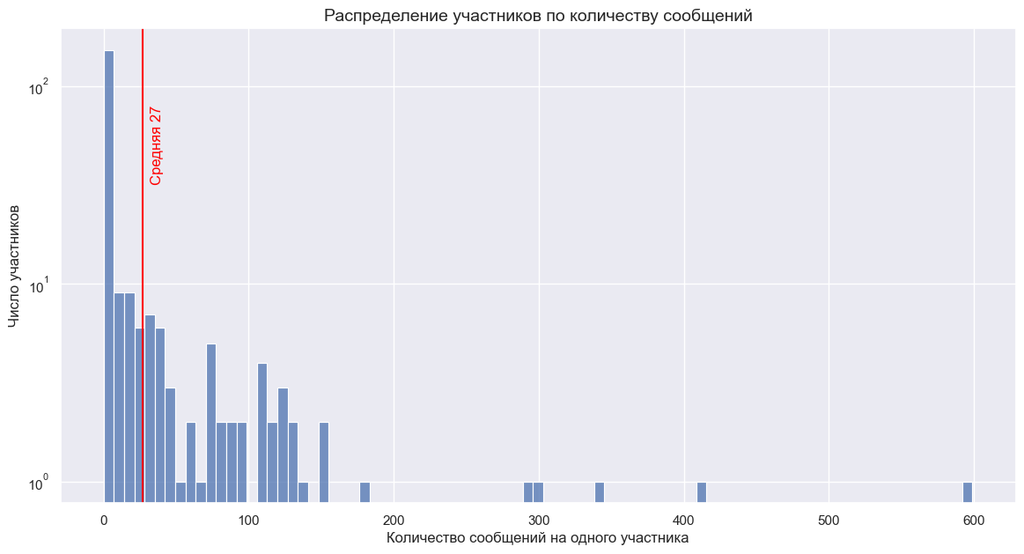

```python
data2211=df_chat[['user', 'message']].groupby('user').agg('count')

fig, ax = plt.subplots(figsize=(14, 7))

g = sns.histplot(
    data=data2211,
    x='message',
    ax=ax
    )
plt.yscale('log')

# Mean line
mean_value = data2211.message.mean()
dummy = ax.axvline(x=mean_value, color="red")
# mean line annotation
dummy = ax.annotate(
    text=f"Средняя {mean_value:.0f}",
    xy=(mean_value+10, 50),  # text position
    xycoords='data',
    horizontalalignment='center',
    verticalalignment='center',
    rotation=90, # Rotation
    color='red', # Color
    alpha=1,
    fontsize=12,
    fontweight="normal")

dummy = plt.title('Распределение участников по количеству сообщений', fontsize=14)
dummy = plt.xlabel('Количество сообщений на одного участника')
dummy = plt.ylabel('Число участников')

plt.show()
```

Описание этого распределения по процентилям

```python
#Quantiles
print("КВАНТИЛИ (ПРОЦЕНТИЛИ)")
arr_q_tiles = np.percentile(data2211, np.arange(10, 101, 10))
for i, n_msgs in enumerate(arr_q_tiles):
    print(f"- {(i+1)/10:.0%} участников: не более {n_msgs:.0f} сообщений от одного человека")
print(f"Медиана (50-й процентиль): 50% участников написале не более {data2211.message.median():.0f} "
      f"сообщений от одного человека")
```

```
КВАНТИЛИ (ПРОЦЕНТИЛИ)
- 10% участников: не более 0 сообщений от одного человека
- 20% участников: не более 0 сообщений от одного человека
- 30% участников: не более 0 сообщений от одного человека
- 40% участников: не более 0 сообщений от одного человека
- 50% участников: не более 0 сообщений от одного человека
- 60% участников: не более 4 сообщений от одного человека
- 70% участников: не более 12 сообщений от одного человека
- 80% участников: не более 34 сообщений от одного человека
- 90% участников: не более 86 сообщений от одного человека
- 100% участников: не более 599 сообщений от одного человека
Медиана (50-й процентиль): 50% участников написале не более 0 сообщений от одного человека
```

### 2.2.2. Динамика активности в чате

У нас нет данных о времени прочентия участниками сообщений в чате. Поэтому, единственным имеющимся способом измерить активность чата может быть количество написанных сообщений на момент времени.

```python
# timespan
n_days = int((df_chat.index.max() - df_chat.index.min()) / np.timedelta64(1, 'D'))
n_weeks = n_days / 7
n_years = n_days / 365
n_hours = n_days * 24
print(f"В чате записаны сообщения за {n_days} дней, что составляет:\n"
      f"{n_weeks:.1f} недель\n"
      f"{n_years:.1f} лет\n"
      f"{n_hours} часов")
```

```
В чате записаны сообщения за 1312 дней, что составляет:
187.4 недель
3.6 лет
31488 часов
```

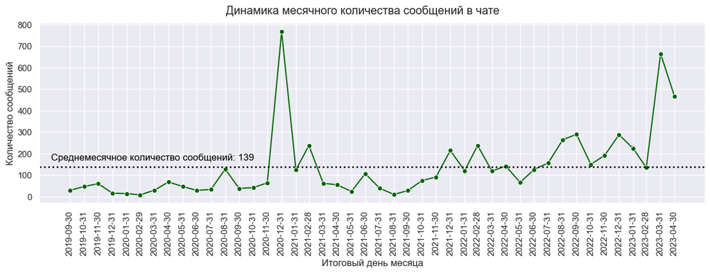

```python
data2221 = df_chat.message.resample('M').count()

g = sns.relplot(data=data2221,
#                 x=data2221.index.date,
#                 y='message',
                height=4,
                aspect=3.2,
                marker='o',
                color='darkgreen',
                kind='line',
                 )
# setting x scale
scale_span_x = pd.date_range(start=data2221.index.min(),
                             end=data2221.index.max(),
                             freq='M').tolist()
dummy = g.set(xticks=scale_span_x)
dummy = g.set_xticklabels(rotation=90)
dummy = g.set_xlabels('Итоговый день месяца', fontsize=12)
dummy = g.set_ylabels('Количество сообщений', fontsize=12)

# mean value line
mean_value=data2221.mean()
#  drawing h line
dummy = g.ax.axhline(mean_value, color='black', linewidth=2, linestyle=':')
dummy = g.ax.annotate(
    text=f"Среднемесячное количество сообщений: {(mean_value):.0f}",
    xy=(0.17, 0.25),  # text position
    xycoords="axes fraction",
    horizontalalignment='center',
    verticalalignment='center',
    rotation=0, # Rotation
    color='black', # Color
    alpha=1,
    fontsize=12,
    fontweight="normal")

dummy = plt.suptitle("Динамика месячного количества сообщений в чате", y=1.025)

plt.show()
```

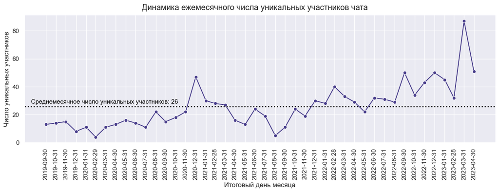

```python
data2222 = df_chat.user.resample('M').nunique()

g = sns.relplot(data=data2222,
                height=4,
                aspect=3.2,
                marker='o',
                color='darkslateblue',
                kind='line',
                 )
# setting x scale
scale_span_x = pd.date_range(start=data2222.index.min(),
                             end=data2222.index.max(),
                             freq='M').tolist()
dummy = g.set(xticks=scale_span_x)
dummy = g.set_xticklabels(rotation=90)
dummy = g.set_xlabels('Итоговый день месяца', fontsize=12)
dummy = g.set_ylabels('Число уникальных участников', fontsize=12)

# mean value line
mean_value=data2222.mean()
#  drawing h line
dummy = g.ax.axhline(mean_value, color='black', linewidth=2, linestyle=':')
dummy = g.ax.annotate(
    text=f"Среднемесячное число уникальных участников: {(mean_value):.0f}",
    xy=(0.17, 0.32),  # text position
    xycoords="axes fraction",
    horizontalalignment='center',
    verticalalignment='center',
    rotation=0, # Rotation
    color='black', # Color
    alpha=1,
    fontsize=11,
    fontweight="normal")

dummy = plt.suptitle("Динамика ежемесячного числа уникальных участников чата", y=1.025)

plt.show()
```

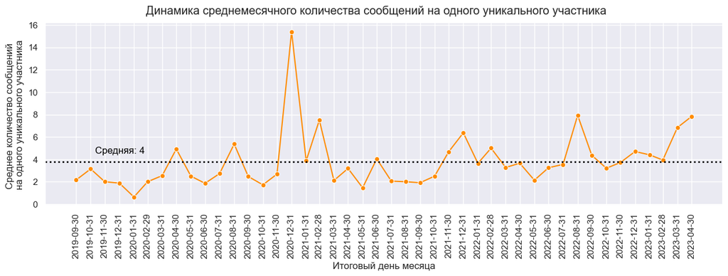

```python
#data2223 = df_chat.user.resample('M').nunique()
data2223 = (
    df_chat[['user', 'message']]
    .resample('M')
    .nunique()
)
data2223 = (
    data2223
    .assign(msg_per_user=data2223.message / data2223.user)
)


g = sns.relplot(data=data2223.msg_per_user,
                height=4,
                aspect=3.2,
                marker='o',
                color='darkorange',
                kind='line',
                 )
# setting x scale
scale_span_x = pd.date_range(start=data2223.index.min(),
                             end=data2223.index.max(),
                             freq='M').tolist()
dummy = g.set(xticks=scale_span_x)
dummy = g.set_xticklabels(rotation=90)
dummy = g.set_xlabels('Итоговый день месяца', fontsize=12)
dummy = g.set_ylabels(f"Среднее количество сообщений \n"
                      f"на одного уникального участника", fontsize=12)

# mean value line
mean_value=data2223.msg_per_user.mean()
#  drawing h line
dummy = g.ax.axhline(mean_value, color='black', linewidth=2, linestyle=':')
dummy = g.ax.annotate(
    text=f"Средняя: {(mean_value):.0f}",
    xy=(0.11, 0.3),  # text position
    xycoords="axes fraction",
    horizontalalignment='center',
    verticalalignment='center',
    rotation=0, # Rotation
    color='black', # Color
    alpha=1,
    fontsize=12,
    fontweight="normal")

dummy = plt.suptitle("Динамика среднемесячного количества сообщений на одного уникального участника", y=1.025)

plt.show()
```

### 2.2.3. Активность в чате по времени суток и по дням недели

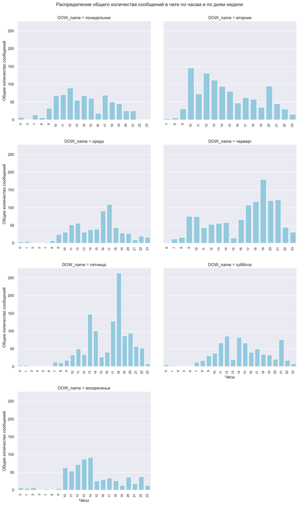

```python
data2231 = (
    df_chat[['message', 'day_of_week', 'DOW_name', 'hour']]
    .groupby(['day_of_week', 'DOW_name', 'hour'], as_index=False)
    .agg('count')
)

g=sns.catplot(data=data2231,
              x='hour',
              y= 'message',
              col='DOW_name',
              col_wrap=2,
              kind='bar',
              errorbar=('ci', False),
              dodge=True,
              sharex=False,
              sharey=True,
              color='skyblue',
              height=5,
              aspect=1.2,
                          )

dummy = plt.suptitle("Распределение общего количества сообщений в чате по часам и по дням недели",
             fontsize=14, x=0.5, y=1)
# Prarmeters:
dummy = g.set_xticklabels(rotation=90, fontsize=10)
dummy = g.set_ylabels('Общее количество сообщений', fontsize=12)
dummy = g.set_xticklabels(size=10)
dummy = g.set_xlabels('Часы', size=12)
dummy = g.set_titles(size=12)

dummy = g.tight_layout(h_pad=3,w_pad=3)
plt.show()
```

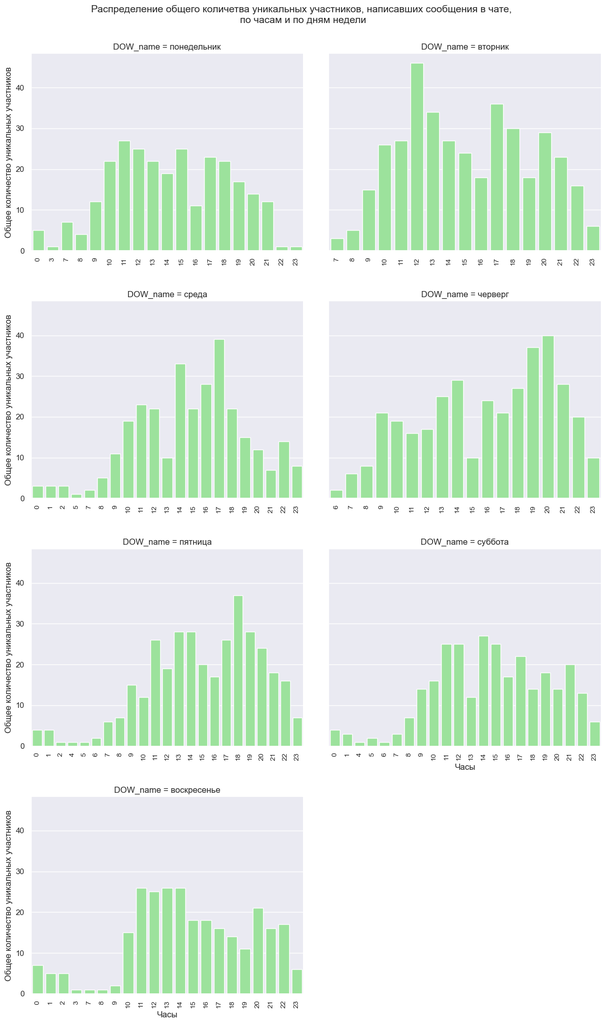

```python
data2232 = (
    df_chat[['user', 'day_of_week', 'DOW_name', 'hour']]
    .groupby(['day_of_week', 'DOW_name', 'hour'], as_index=False)
    .agg('nunique')
)

g=sns.catplot(data=data2232,
              x='hour',
              y= 'user',
              col='DOW_name',
              col_wrap=2,
              kind='bar',
              errorbar=('ci', False),
              dodge=True,
              sharex=False,
              sharey=True,
              color='lightgreen',
              height=5,
              aspect=1.2,
                          )

dummy = plt.suptitle(f"Распределение общего количетва уникальных участников, написавших сообщения в чате, \n"
                     f"по часам и по дням недели",
             fontsize=14, x=0.5, y=1.0)
# Prarmeters:
dummy = g.set_xticklabels(rotation=90, fontsize=10)
dummy = g.set_ylabels('Общее количество уникальных участников', fontsize=12)
dummy = g.set_xticklabels(size=10)
dummy = g.set_xlabels('Часы', size=12)
dummy = g.set_titles(size=12)

dummy = g.tight_layout(h_pad=3,w_pad=3)
plt.show()
```

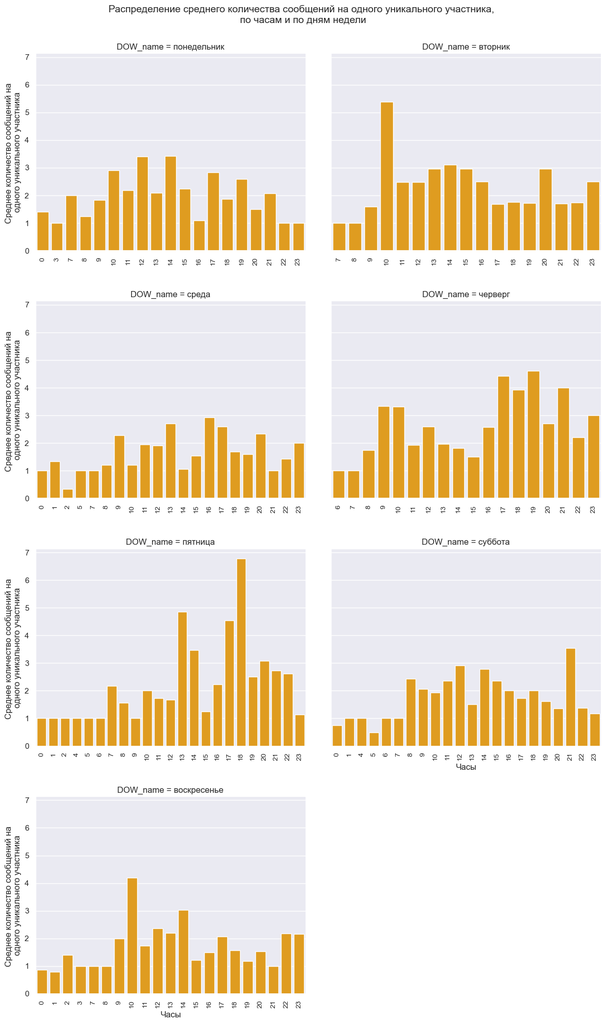

```python
data2233 = (
    df_chat[['user', 'message', 'day_of_week', 'DOW_name', 'hour']]
    .groupby(['day_of_week', 'DOW_name', 'hour'], as_index=False)
    .agg('nunique')
)
data2233 = (
    data2233
    .assign(msg_per_user = data2233.message / data2233.user)
)

g=sns.catplot(data=data2233,
              x='hour',
              y= 'msg_per_user',
              col='DOW_name',
              col_wrap=2,
              kind='bar',
              errorbar=('ci', False),
              dodge=True,
              sharex=False,
              sharey=True,
              color='orange',
              height=5,
              aspect=1.2,
                          )

dummy = plt.suptitle(f"Распределение среднего количества сообщений на одного уникального участника, \n"
                     f"по часам и по дням недели",
             fontsize=14, x=0.5, y=1.0)
# Prarmeters:
dummy = g.set_xticklabels(rotation=90, fontsize=10)
dummy = g.set_ylabels(f'Среднее количество сообщений на \n'
                      f'одного уникального участника', fontsize=12)
dummy = g.set_xticklabels(size=10)
dummy = g.set_xlabels('Часы', size=12)
dummy = g.set_titles(size=12)

dummy = g.tight_layout(h_pad=3,w_pad=3)
plt.show()
```

# 3. Анализ содержания сообщений

В данном разделе комментарие к коду будут, в основном, на русском языке

## 3.1. Лексический анализ

### 3.1.1. Частотные характеристики словоупотребления

```python
# ОБРАБОТКА ТЕКСТОВ ИЗ DF ДЛЯ СОЗДЕНИЯ СПИСКА НОРМАЛИЗОВАННЫХ ЗНАЧИМЫХ СЛОВ

# Глобальные определения:
# Вызов метода .MorphAnalyzer() библиотеки pymorphy2:
morph = pymorphy2.MorphAnalyzer()
# Шаблон регулярного выражения для вычленения отдельных слов (любой из перечисленных символов до конца слова):
# regex_word =  re.compile(r'[a-zA-Zа-яА-ЯёЁ]+\b')
regex_word =  re.compile(r'[^\d\W]+\b')
# Шаблон регулярного выражения для удаления гиперссылок:
regex_no_http = re.compile(r'http[s]?://\S+', flags=re.MULTILINE)
# Шаблон регулярного выражения для удаления служебных маркеров WhatsApp:
regex_no_wp_arrow = re.compile(r'\u200e')

# Список исходных текстов из DF
list_init_texts = []
# Список текстов из приведенных к исходной форме слов,
# кроме служебных частей речи и именных местоимений (список нормализованных значимых частей речи):
list_norm_сlean_texts = []

# Функция для определения частей речи
def pos(word):
    """ возрвращает вероятную часть речи для аргумента word """
    return morph.parse(word)[0].tag.POS

# Функция разбиения текста в список слов
def norm_clean_low_words_maker(text=""):
    """ Функция разбиения текста в список слов, приведённых к нижнему регистру,
    за исключегием служебных частей речи (междометия, частицы, союзы, предлоги), а также личных местоимений """
    # Приводим исходный текст к нижнему регистру
    try: # (обработка ошибок, если в тексте попадётся NaN)
        lowered_text = text.lower()
    except:
        print('error is here!', text)

    # Удалаем из текста все гиперссылки и служебные стрелки WhatsApp:
    no_junk_text = re.sub(regex_no_http, '', lowered_text)
    # Удалаем из текста все служебные стрелки WhatsApp:
    no_junk_text = re.sub(regex_no_wp_arrow, '', no_junk_text)

    # Разбиваем текст на слова:
    # применяем метод findall для поиска всех совпадений с шаблоном регулярного выражения в тексте,
    list_words = regex_word.findall(no_junk_text)

    # Исключаем из текста междометия, частицы, союзы, предлоги, именные местоимения:
    # граммемы русского языка: для исключения
     # междометия, частицы, союзы, предлоги, личные местоимения
    functors_pos = {'INTJ', 'PRCL', 'CONJ', 'PREP', 'NPRO'}

    # проверяем и нормализуем слова
    list_norm_clean_low_words=[] # список нормализованных слов в нижнем регистре кроме служебных частей речи
    for word in list_words:
        # если результат вызова функции не является служебной частью речи или именным местоимением
        if pos(word) not in functors_pos:
            # приводим слово к исходной форме (normalized)
            parsed_word = morph.parse(word) # результат вызова morph - список из разных элементов
            normalized_word = parsed_word[0].normal_form # выбираем исходную форму слова из результата вызова morph
            # добавляем исходную форму проверенного слова в список исходных форм
            list_norm_clean_low_words.append(normalized_word) # добавляем проверенное слово в список
    return list_norm_clean_low_words

# форимируем исходный список текстов из df_chat, заменив NaN на ''
list_init_texts = df_chat.message.fillna('').tolist()

# Получим список текстов из нормализованных значимых частей речи за счёт
# применения функции norm_clean_low_words_maker к каждому элементу (тексту) в начальном списке текстов list_init_texts

list_norm_сlean_texts = list(map(norm_clean_low_words_maker, list_init_texts))

# результат
# print (list_norm_сlean_texts)
```

```python
# Сгенерируем для df_chat уникальные индексы сообщений msg_id
df_chat = (
    df_chat
    .assign(
        msg_id = np.arange(0, len(df_chat), 1)
    )
)
df_chat.sample(7)
```

| date_time | user | message | action | day_of_week | DOW_name | hour | msg_id |
| --- | --- | --- | --- | --- | --- | --- | --- |
| 2023-02-20 10:00:00 | +7 915 002-53-33 | А на какой линии? | NaN | 0 | понедельник | 10 | 5041 |
| 2022-06-28 12:24:00 | +7 985 444-72-00 | Вот квест у СПК сегодня))) теперь деревья разг... | NaN | 1 | вторник | 12 | 3339 |
| 2023-03-28 13:38:00 | +7 985 769-03-22 | Добавьте в опрос опцию " не могу ответить, нед... | NaN | 1 | вторник | 13 | 5313 |
| 2022-07-10 11:43:00 | +7 915 002-53-33 | Блин, это размер!!! | NaN | 6 | воскресенье | 11 | 3440 |
| 2020-12-31 10:26:00 | +7 985 769-03-22 | Ваши, может быть, и не будут. Но многие, к сож... | NaN | 3 | черверг | 10 | 1442 |
| 2022-09-27 13:40:00 | +7 915 002-59-99 | http://knetwork.ru/ | NaN | 1 | вторник | 13 | 4031 |
| 2022-09-25 13:05:00 | +7 929 643-30-90 | <Без медиафайлов> | NaN | 6 | воскресенье | 13 | 3990 |

```python
# Содадим DF с ID сообщений и соответствующими им нормализованными словами
# Создадим список ID сообщений df_chat (cоответствующий индексам list_init_texts и list_norm_сlean_texts)
list_msg_idx = np.arange(0, len(df_chat), 1)

# Для создания DF из списка кортежей, определим такой список кортежей
list_of_tuples = []
for i, text in enumerate(list_norm_сlean_texts): # для каждого i и текста в списке нормализованных значимых слов
    for word in text: # для каждого слово в таком тексте
        # соединим в кортеже ID сообщения и слово, добавим кортеж в список
        list_of_tuples.append(tuple([list_msg_idx[i], word]))

# Создадим DF на основе списка кортежей, обозначим названия столбцов
df_norm_words = pd.DataFrame(list_of_tuples, columns=['msg_id', 'words'])

df_norm_words.shape
df_norm_words.sample(7)
```

```
(42923, 2)
```

|  | msg_id | words |
| --- | --- | --- |
| 34127 | 5360 | товарищество |
| 29676 | 4651 | хороший |
| 9457 | 1401 | некоторый |
| 36344 | 5629 | особенно |
| 14519 | 2264 | разводить |
| 34094 | 5351 | инф |
| 14948 | 2314 | деревня |

```python
# Создадим DF с подсчётом встречаемости нормализованных слов (по убыванию) среди всех сообщений:
# - группируем по словам,
# - агрегируем с подсчётом количества сообщений для каждодго слова,
# переименовываем post_id по смыслу: "частота встречаемости слова",
# - сортируем частоты по убыванию:
df_norm_words_occurrence = (
    df_norm_words
    .groupby(["words"], as_index=False)
    .agg('count')
    .rename(columns={"msg_id":"word_occurrence_freq"})
    .sort_values(by="word_occurrence_freq", ascending=False)
)

df_norm_words_occurrence.head(25)
```

|  | words | word_occurrence_freq |
| --- | --- | --- |
| 478 | быть | 866 |
| 2805 | медиафайл | 647 |
| 2964 | мочь | 389 |
| 1584 | есть | 374 |
| 561 | весь | 362 |
| 3361 | нет | 300 |
| 3210 | наш | 271 |
| 6001 | снт | 253 |
| 3052 | надо | 252 |
| 7378 | этот | 237 |
| 6938 | участок | 237 |
| 1586 | ещё | 237 |
| 6556 | только | 234 |
| 1472 | дорога | 223 |
| 1402 | добрый | 222 |
| 6766 | уже | 215 |
| 758 | вопрос | 210 |
| 1129 | год | 207 |
| 6577 | тот | 204 |
| 6090 | сообщение | 204 |
| 2186 | какой | 203 |
| 6430 | такой | 202 |
| 1322 | день | 200 |
| 1262 | данный | 191 |
| 6435 | там | 181 |

```python
# Создадим DF с разбивкой по индексам сообщений и указанием втречаемости каждого слова из сообщения
# в общем массиве слов
# - объединим DFs с ID публикаций и встречаемостью слов по полю "слова"
# - отсортируем по ID публикаций и встречаемости слов в убывающем порядке
df_norm_words_occurrence_by_msg = (
    df_norm_words.merge(df_norm_words_occurrence, on="words", how='left')
    .sort_values(by=["msg_id","word_occurrence_freq"], ascending=False)
)
df_norm_words_occurrence_by_msg.sample(7)
```

|  | msg_id | words | word_occurrence_freq |
| --- | --- | --- | --- |
| 14154 | 2175 | быстрый | 4 |
| 13030 | 2011 | член | 58 |
| 6381 | 959 | нет | 300 |
| 37338 | 5717 | устав | 29 |
| 5587 | 905 | иметься | 8 |
| 38826 | 5867 | камера | 52 |
| 36522 | 5645 | территория | 81 |

#### 3.1.1.1 Расперделение слов по частотным характеристикам

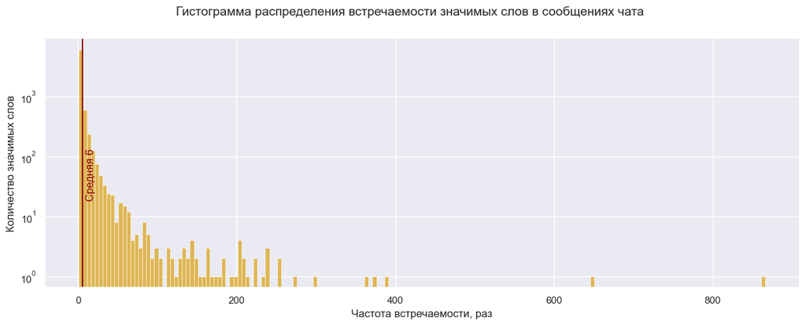

```python
# Построим гистограмму распределения количества значимых слов по встречаемости в сообщениях
fig, ax = plt.subplots(figsize=(15,5), ncols=1, nrows=1)
g = sns.histplot(data=df_norm_words_occurrence,
                 x="word_occurrence_freq",
                 binwidth=5,
                 color='goldenrod',
                 ax=ax)

# Mean line
mean_value = df_norm_words_occurrence.word_occurrence_freq.mean()
dummy = ax.axvline(x=mean_value, color="darkred")
# mean line annotation
dummy = ax.annotate(
    text=f"Средняя {mean_value:.0f}",
    xy=(mean_value+10, 50),  # text position
    xycoords='data',
    horizontalalignment='center',
    verticalalignment='center',
    rotation=90, # Rotation
    color='darkred', # Color
    alpha=1,
    fontsize=12,
    fontweight="normal")


dummy = ax.set_yscale('log')
dummy = ax.set_xlabel('Частота встречаемости, раз', fontsize=12)
dummy = ax.set_ylabel('Количество значимых слов', fontsize = 12)
dummy = plt.suptitle(f"Гистограмма распределения встречаемости значимых слов в сообщениях чата",
                     fontsize=14)
plt.show()
```

Как видно из графика, у нас есть выбросы по частоте встречаемости. Определим перечень этих слов.

```python
# calculate word frequences beyond 3-sigma limit
sigma = df_norm_words_occurrence.word_occurrence_freq.std()
df_norm_words_occurrence[df_norm_words_occurrence.word_occurrence_freq > sigma*3]
```

|  | words | word_occurrence_freq |
| --- | --- | --- |
| 478 | быть | 866 |
| 2805 | медиафайл | 647 |
| 2964 | мочь | 389 |
| 1584 | есть | 374 |
| 561 | весь | 362 |
| 3361 | нет | 300 |
| 3210 | наш | 271 |
| 6001 | снт | 253 |
| 3052 | надо | 252 |
| 7378 | этот | 237 |
| 6938 | участок | 237 |
| 1586 | ещё | 237 |
| 6556 | только | 234 |
| 1472 | дорога | 223 |
| 1402 | добрый | 222 |
| 6766 | уже | 215 |
| 758 | вопрос | 210 |
| 1129 | год | 207 |
| 6577 | тот | 204 |
| 6090 | сообщение | 204 |
| 2186 | какой | 203 |
| 6430 | такой | 202 |
| 1322 | день | 200 |
| 1262 | данный | 191 |
| 6435 | там | 181 |
| 2912 | можно | 181 |
| 6798 | улица | 180 |
| 6736 | удалить | 173 |
| 6109 | сосед | 166 |
| 1448 | дом | 164 |

[output cut: 54 more lines]

```python
volcabulary = (
    df_norm_words_occurrence
    .words
    .count()
)
frequent_words = (
    df_norm_words_occurrence
    .word_occurrence_freq[df_norm_words_occurrence.word_occurrence_freq <= 20]
    .count()
)
most_freq_words = (
    df_norm_words_occurrence
    .word_occurrence_freq[df_norm_words_occurrence.word_occurrence_freq > 20]
    .count()
)

print("Объем словаря значимых слов: ", volcabulary,
      "\n20 и менее раз используется: ", frequent_words,
      "\nБолее 20 раз используется: ", most_freq_words,
      f'\n50% Значимых слов встречаются не более {df_norm_words_occurrence.word_occurrence_freq.median()} раз(-а)')
```

```
Объем словаря значимых слов:  7419
20 и менее раз используется:  7079
Более 20 раз используется:  340
50% Значимых слов встречаются не более 1.0 раз(-а)
```

**Таки образом**

Примечательно, что наиболее употребимым является слово "быть", не имеющее специфического значения. Оно встречается 866 раз. Так же выделяется слово "медиафайл" - это сообщения содержащие только изображения, аудио или видео. Всего таких медиафайлов 647. По списку перечню слов с очень высокой частотой встречамости можно будет судить о наиболее актуальных темах для участников чата. Сделаем это нескольео позже.

#### 3.3.3.2. Характеристика сообщений по средней частоте встречаемости используемых слов

Для определения, в какой мере та или иная публикация использует часто встречаемые слова, введём усреднённый показатель: средняя встречаемость слов в сообщении. Для его получения сумму частот встречаемости каждого значимого слова в сообщении разделим на количество значимых слов в этом сообщении.

```python
# Создадим отедльный DF для данного подраздела.
# Для этог группируем df_norm_words_occurrence_by_msg по msg_id, подсчитываем в них значимые слова и

# вычисляем сумму встречаемости слов.
data3332 = df_norm_words_occurrence_by_msg.groupby(["msg_id"], as_index=False)\
.agg({"words":'count', "word_occurrence_freq":'sum'})

# Добавляем новый столбец для средней встречаемости слов в сообщении
data3332["avg_word_occurrence"] = data3332.word_occurrence_freq / data3332.words

# Переименовываем столбцы по смыслу
data3332.rename(columns={"words":"words_count", "word_occurrence_freq":"total_word_occurrence"}, inplace=True)

# Сохраним индекс df_chat
df_chat_idx = df_chat.index

# Добавим данные о средней встречаемости слов в публикации в df_chat
df_chat = df_chat.merge(data3332, on="msg_id", how='left')
# восстановим индекс в df_chat
df_chat.set_index(df_chat_idx, inplace=True)

data3332.sample(3)
df_chat.sample(3)
```

|  | msg_id | words_count | total_word_occurrence | avg_word_occurrence |
| --- | --- | --- | --- | --- |
| 3771 | 4242 | 1 | 2 | 2.000000 |
| 471 | 548 | 33 | 1326 | 40.181818 |
| 2505 | 2831 | 2 | 49 | 24.500000 |

| date_time | user | message | action | day_of_week | DOW_name | hour | msg_id | words_count | total_word_occurrence | avg_word_occurrence |
| --- | --- | --- | --- | --- | --- | --- | --- | --- | --- | --- |
| 2023-04-02 10:20:00 | +7 929 552-10-20 | Что устанавливают, кто? | NaN | 6 | воскресенье | 10 | 5843 | 1.0 | 4.0 | 4.000000 |
| 2022-05-25 16:03:00 | +7 915 134-67-88 | Добрый день! Подскажите, пожалуйста, тариф на ... | NaN | 2 | среда | 16 | 3255 | 9.0 | 773.0 | 85.888889 |
| 2022-03-11 18:15:00 | +7 977 839-40-24 | У нас к- нект минимальный тариф 800р , один в... | NaN | 4 | пятница | 18 | 3032 | 15.0 | 493.0 | 32.866667 |

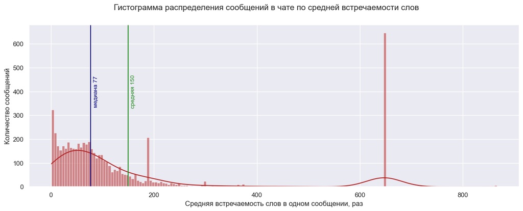

```python
# Построим гистограмму распределения сообщений по средней встречаемости слов
fig, ax = plt.subplots(figsize=(15,5), ncols=1, nrows=1)
g=sns.histplot(
    data=data3332,
    x="avg_word_occurrence",
    binwidth=5,
    kde=True,
    color='firebrick',
    ax=ax)


dummy = ax.set_xlabel('Средняя встречаемость слов в одном сообщении, раз', fontsize=12)
dummy = ax.set_ylabel('Количество сообщений', fontsize = 12)

# Прочертим линию средней
mean_value = data3332.avg_word_occurrence.mean()
dummy = ax.axvline(x=mean_value, color="forestgreen")
# Создание подписи
dummy = ax.annotate(
    text=f"средняя {mean_value:.0f}",
    xy=(mean_value+10, 400),  # Положение подписи (чтобы не перекрывать точки графика)
    xycoords='data',
    horizontalalignment='center',  # Выравнивание текста по горизонтали
    verticalalignment='center',  # Выравнивание текста по вертикали
    rotation=90, # Поворот подписи
    color='forestgreen', # Цвет надписи
    alpha=1,
    fontsize=10,
    fontweight="normal")

# Прочертим линию медианы
median_value = data3332.avg_word_occurrence.median()
dummy = ax.axvline(x=median_value, color="navy")
# Создание подписи
dummy = ax.annotate(
    text=f"медиана {median_value:.0f}",
    xy=(median_value+10, 400),  # Положение подписи (чтобы не перекрывать точки графика)
    xycoords='data',
    horizontalalignment='center',  # Выравнивание текста по горизонтали
    verticalalignment='center',  # Выравнивание текста по вертикали
    rotation=90, # Поворот подписи
    color='navy', # Цвет надписи
    alpha=1,
    fontsize=10,
    fontweight="normal")

dummy = plt.suptitle('Гистограмма распределения сообщений в чате по средней встречаемости слов',
            fontsize=14)
plt.show()
```

### 3.2. Анализ смысловой окрашенности сообщений

Существует целый ряд слов, которые носят позитивную или негативную смысловую окраску. При соответствующих знаниях в области прикладной психологии (например, neuro-linguistic programming - применительно к коммуникации), можно выявить сильные мотивирующие или демотивирующие тексты. Интересно будет выявить, в какой мере слова с различной смысловой окраской используются в сообщениях в чате.

> **ПРИМЕЧАНИЕ** Словари негативных и позитивных слов, которые удалось найти автору, разилчаются по своему объёму: словарь позитивных слов намного шире, словаря негативных слов. Поэтому определение степени негативности текстов может быть искажёно в сторону улучшения результата.

### 3.2.1. Создание перечней позитивно и негативно окрашенных слов

```python
# Функция чтения текста по URL адерсу (использует библиотеку bs4 BeautifulSoup)
def get_text(url):
    rs = requests.get(url)
    root = BeautifulSoup(rs.content, 'html.parser')
    article = root.select_one('article')
    return article.text

url = "https://everychild.ru/reyting/horoshie-slova-v-russkom-yazyke-primery/"
positive_words_text = get_text(url)
#print(positive_words_text)
```

Полученный текст необходимо очистить от вступления, заключения и повторяющихся вставок-алфавитных разделителей, а также нормализовать.

> **ПРИМЕЧАНИЕ**  
> Приведенный ниже код не универсальный, а создан именно для данного текста

```python
# регулярные выражения для удаления частей текста.
list_regex = [r'\n+', # 1 и более символов перевода строки
                 r'(.*)(?=абсолютно)', # любые символы, кроме перевода строки, до слова "абсолютно"
                 r'(?<=ясный)(.*)', # любые символы, кроме перевода строки, после слова "ясный"
                 r'положительные слова, которые начинаются с .?', # любой символ (одно повторение после "начинаются с ")
                 r'положительные слова, которые начинаются .?'] #любой символ (одно повтроение после "начинаются ")
                 # вычленить слова

for regex in list_regex:
    positive_words_text = re.sub(regex, ' ', positive_words_text) # выполняем замену найденных строк на пробелы
#print(positive_words_text)

# Вычленим слова, очистим от служебных частей речи, нормализуем (аналогично функции norm_clean_low_words_maker)
regex = re.compile(r'\w+')  # вычленить слова

list_positive_words = regex.findall(positive_words_text)
# нормализуем список:
# грамемы русского языка: для исключения
# междометия, частицы, союзы, предлоги, личные местоимения
functors_pos = {'INTJ', 'PRCL', 'CONJ', 'PREP', 'NPRO'}
# проверяем и нормализуем слова
list_norm_clean_positive_words=[] # список нормализованных слов в нижнем регистре кроме служебных частей речи
for word in list_positive_words:
    # если результат вызова функции не является служебной частью речи или именным местоимением
    if pos(word) not in functors_pos:
        # приводим слово к исходной форме (normalized)
        parsed_word = morph.parse(word) # результат вызова morph - список из разных элементов
        normalized_word = parsed_word[0].normal_form # выбираем исходную форму слова из результата вызова morph
        # добавляем исходную форму проверенного слова в список исходных форм
        list_norm_clean_positive_words.append(normalized_word) # добавляем проверенное слово в список

#print(norm_clean_positive_words_list)
```

```python
# Сохраним список положительных слов в формате joblib
joblib.dump(list_norm_clean_positive_words, "data/list_positive_words.joblib")
list_norm_clean_positive_words[:25]
```

```
['data/list_positive_words.joblib']
```

```
['абсолютно',
 'адаптироваться',
 'аккуратность',
 'аккуратный',
 'активизироваться',
 'активный',
 'альтруистический',
 'ангельский',
 'аутентичный',
 'баланс',
 'безмятежность',
 'безмятежный',
 'безопасный',
 'бесконечность',
 'бесконечный',
 'беспристрастный',
 'бесстрашный',
 'бесценный',
 'благодарный',
 'радость',
 'благодарность',
 'благодарный',
 'благоприятный',
 'благородный',
 'благосклонный']
```

Сопоставим каждое слово в df_norm_words_count_by_post и df_norm_words_occurrence со списком нормализованных позитивных слов list_norm_clean_positive_words.

```python
df_norm_words_occurrence_by_msg = (
    df_norm_words_occurrence_by_msg
    .assign(
        positive = (df_norm_words_occurrence_by_msg
                  .words
                  .apply(lambda x: x in list_norm_clean_positive_words))
    )
)
df_norm_words_occurrence = (
    df_norm_words_occurrence
    .assign(positive = (df_norm_words_occurrence
                        .words
                        .apply(lambda x: x in list_norm_clean_positive_words))
           )
)
```

```python
df_norm_words_occurrence_by_msg[df_norm_words_occurrence_by_msg.positive == True].sample(3)
```

|  | msg_id | words | word_occurrence_freq | positive |
| --- | --- | --- | --- | --- |
| 2420 | 468 | сейчас | 143 | True |
| 34387 | 5372 | сейчас | 143 | True |
| 21620 | 3214 | любовь | 8 | True |

```python
df_norm_words_occurrence[df_norm_words_occurrence.positive == True].sample(3)
```

|  | words | word_occurrence_freq | positive |
| --- | --- | --- | --- |
| 6686 | убедительный | 1 | True |
| 1933 | зелёный | 4 | True |
| 4970 | принятие | 4 | True |

> **ПРИМЕЧАНИЕ**
> 1. Список слов сохранён в файл MS Excel.
> 2. Слова уже нормализованы.

```python
# Создадим список негативных слолв, прочитав его из файла Excel
list_negative_words = pd.read_excel("data/negative_words.xlsx", header=0, index_col=0, usecols=[0,1]).word.tolist()
#list_negative_words
```

Сопоставим каждое слово в df_norm_words_occurrence_by_post и в df_norm_words_occurrence со списком нормализованных негативных слов negative_word_list.

```python
df_norm_words_occurrence_by_msg = (
    df_norm_words_occurrence_by_msg
    .assign(
        negative = (df_norm_words_occurrence_by_msg
                    .words
                    .apply(lambda x: x in list_negative_words))
    )
)
df_norm_words_occurrence = (
    df_norm_words_occurrence
    .assign(
        negative = (
            df_norm_words_occurrence
            .words
            .apply(lambda x: x in list_negative_words))
    )
)
```

```python
df_norm_words_occurrence_by_msg[df_norm_words_occurrence_by_msg.negative == True].sample(3)
```

|  | msg_id | words | word_occurrence_freq | positive | negative |
| --- | --- | --- | --- | --- | --- |
| 13029 | 2011 | обязанность | 5 | False | True |
| 11932 | 1821 | кража | 4 | False | True |
| 21223 | 3117 | беспокойство | 2 | False | True |

```python
df_norm_words_occurrence[df_norm_words_occurrence.negative == True].sample(3)
```

|  | words | word_occurrence_freq | positive | negative |
| --- | --- | --- | --- | --- |
| 1151 | горе | 1 | False | True |
| 733 | война | 9 | False | True |
| 3236 | негатив | 5 | False | True |

### 3.2.2. Расперделение позитивных и негативных слов по частотным характеристикам

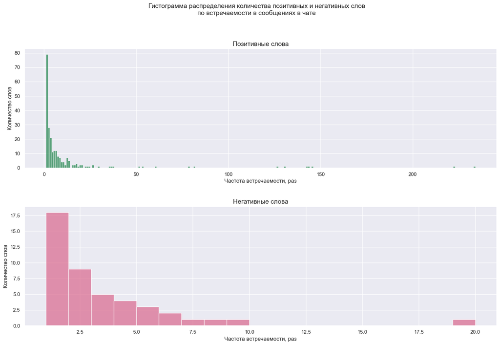

```python
# Построим гистограмму распределения количества позитивных и негативных слов по встречаемости в публикациях
fig, ax = plt.subplots(figsize=(15,9), ncols=1, nrows=2)
fig.tight_layout(h_pad=5)
data1 = df_norm_words_occurrence[df_norm_words_occurrence.positive==True]
data2 = df_norm_words_occurrence[df_norm_words_occurrence.negative==True]
param_list=[[data1, 'seagreen', "Позитивные слова"], [data2,'palevioletred', "Негативные слова"]]

for i, param in enumerate(param_list):
    g = sns.histplot(
        data=param[0],
        x="word_occurrence_freq",
        binwidth=1,
        color=param[1],
        ax=ax[i])

    dummy = ax[i].set_xlabel('Частота встречаемости, раз', fontsize=12)
    dummy = ax[i].set_ylabel('Количество слов', fontsize = 12)
    dummy = ax[i].set_title(f"{param[2]}", fontsize = 14)


dummy = plt.suptitle(f"Гистограмма распределения количества позитивных и негативных слов\n"
             f"по встречаемости в сообщениях в чате",
            fontsize=14, y=1.125)
plt.show()
```

```python
vocabulary = df_norm_words_occurrence.words.count()
positive_voc = df_norm_words_occurrence.positive.sum()
negative_voc = df_norm_words_occurrence.negative.sum()
print(f"Общее количество позитивных слов в словарном запасе: {positive_voc}, "
      f"то есть {(positive_voc/vocabulary*100):.2f}%")
print(f"Общее количество негативных слов в словарном запасе: {negative_voc}, "
      f"то есть {(negative_voc/vocabulary*100):.2f}%")
```

```
Общее количество позитивных слов в словарном запасе: 233, то есть 3.14%
Общее количество негативных слов в словарном запасе: 45, то есть 0.61%
```

### 3.2.3. Характеристика сообщений по степени позитивности и негативности

Проанализируем соотношение позитивных и негативных слов к общему числу слов в каждой отдельной публикации. В отличие от средней встречаемости слов в публикации, которая показывала, насколько та или иная публикация использует часто встречаемые слова, здесь мы выясним общую степень "позитивности" и "негативности" каждой публикаций.

```python
# Создадим отедльный DF для данного подраздела.
# Для этого:

# - в новом DF группируем df_norm_words_occurrence_by_msg по номерам сообщений,
# - подсчитываем в них значимые позитивные и негативные слова и
# - вычисляем отношения количества позитивных и негативных слов к общему числу слов в сообщении.
df_323=df_norm_words_occurrence_by_msg.drop(columns="word_occurrence_freq")
df_323=df_norm_words_occurrence_by_msg.groupby(["msg_id"])\
.agg({"words":'count', "positive":'sum', "negative":'sum'})

# Добавляем новые столбцы для доли позитивных и негативных слов в общем количестве слов в сообщении
df_323["pos_fraction"] = df_323.positive / df_323.words
df_323["neg_fraction"] = df_323.negative / df_323.words

# Переименовываем столбцы по смыслу
df_323.rename(columns={"words":"words_count", "word_occurrence_freq":"total_word_occurrence",
                       "positive":"pos_word_count", "negative":"neg_word_count"}, inplace=True)
df_323.sample(5)
```

| msg_id | words_count | pos_word_count | neg_word_count | pos_fraction | neg_fraction |
| --- | --- | --- | --- | --- | --- |
| 3619 | 26 | 1 | 1 | 0.038462 | 0.038462 |
| 271 | 8 | 0 | 0 | 0.000000 | 0.000000 |
| 5657 | 1 | 0 | 0 | 0.000000 | 0.000000 |
| 5091 | 7 | 1 | 0 | 0.142857 | 0.000000 |
| 6275 | 1 | 0 | 0 | 0.000000 | 0.000000 |

```python
# Добавим данные о доле позитивных и негативных слов в сообщениях в df_chat
df_chat = df_chat.merge(df_323[["pos_fraction", "neg_fraction" ]], on="msg_id", how='left')
# восстановим индекс в df_chat
df_chat.set_index(df_chat_idx, inplace=True)
df_chat.sample(1)
```

| date_time | user | message | action | day_of_week | DOW_name | hour | msg_id | words_count | total_word_occurrence | avg_word_occurrence | pos_fraction | neg_fraction |
| --- | --- | --- | --- | --- | --- | --- | --- | --- | --- | --- | --- | --- |
| 2022-08-08 15:38:00 | +7 915 449-73-74 | Если короткое замыкание было после электрощита... | NaN | 0 | понедельник | 15 | 3645 | 35.0 | 3081.0 | 88.028571 | 0.0 | 0.0 |

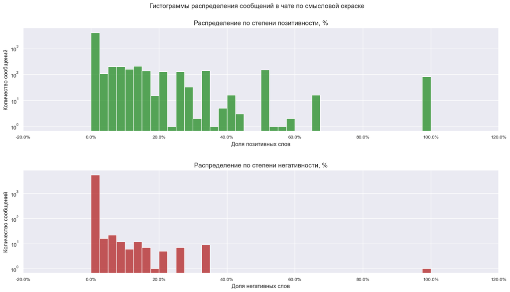

```python
fig, ax = plt.subplots(figsize=(15,8), ncols=1, nrows=2)
fig.tight_layout(h_pad=5)
data = df_323
list_param=[["pos_fraction", 'forestgreen', "позитивности", "позитивных"],
            ["neg_fraction",'firebrick', "негативности", "негативных"]]

for i, param in enumerate(list_param):
    g = sns.histplot(
        data=data,
        x=param[0],
        binwidth=0.025,
        color=param[1],
        ax=ax[i])

    dummy = ax[i].set_xlabel(f"Доля {param[3]} слов", fontsize=12)
    dummy = ax[i].set_ylabel('Количество сообщений', fontsize = 12)
    dummy = ax[i].set_title(f"Распределение по степени {param[2]}, %", fontsize = 14)
    # изменим подписи шкалы Y, определим их в процнтах
    # а) исправляем User Warning: FixedFormatter should only be used together with FixedLocator заново устанавливае yticks
    ticks_loc = ax[i].get_xticks().tolist()
    dummy = ax[i].set_xticks(ticks_loc)
    # б) устанавливаем формат и значения
    xlabels = [f"{(y * 100):.1f}%" for y in ticks_loc]
    dummy = ax[i].set_xticklabels(xlabels, fontsize=10)
    dummy = ax[i].set_yscale('log')
dummy = plt.suptitle(f"Гистограммы распределения сообщений в чате по смысловой окраске",
            fontsize=14, y=1.0625)
plt.show()
```

```python
texts_num=df_chat.msg_id.count()
texts_pos = df_323.pos_fraction[df_323.pos_fraction != 0].count()
texts_neg = df_323.neg_fraction[df_323.neg_fraction != 0].count()
print(f"Общее количество сообщений {texts_num} \n"
      f"Общее количество сообщений, содержащих позитивные слова {texts_pos}, "
      f"то есть {(texts_pos/texts_num*100):.1f}%\n"
      f"Общее количество сообщений, содержащих негативные слова {texts_neg}, "
      f"то есть {(texts_neg/texts_num*100):.1f}%", )
```

```
Общее количество сообщений 6301
Общее количество сообщений, содержащих позитивные слова 1734, то есть 27.5%
Общее количество сообщений, содержащих негативные слова 110, то есть 1.7%
```

### 3.2.4. Группировка участников по степени смысловой окрашенности сообщений

ПРИМЕЧАНИЕ

> Группировка по позитивной и по негативной смысловой окрашенности сообщений производятся раздельно и независимо друг от друга, поэтому участники могут упоминаться в обеих группировках одновременно.

```python
df_324 = (
    df_chat[['user', "pos_fraction", "neg_fraction"]]
    .dropna(subset=["pos_fraction", "neg_fraction"])
    .groupby('user', as_index=False)
    .agg('mean')
)
```

```python
print("15 участников с максимальной средней ПОЗИТИВНОЙ смысловой окраской сообщений")
(
    df_324[['user','pos_fraction']]
    .sort_values(by=['pos_fraction'], ascending=False)
    .nlargest(15, 'pos_fraction')
)
```

```
15 участников с максимальной средней ПОЗИТИВНОЙ смысловой окраской сообщений
```

|  | user | pos_fraction |
| --- | --- | --- |
| 16 | +7 905 709-53-83 | 0.458874 |
| 86 | +7 964 780-02-27 | 0.373568 |
| 2 | +7 903 170-62-90 | 0.333333 |
| 98 | +7 977 839-40-24 | 0.304762 |
| 63 | +7 925 154-61-34 | 0.175967 |
| 46 | +7 916 675-72-39 | 0.145933 |
| 24 | +7 915 134-67-88 | 0.138292 |
| 37 | +7 916 500-70-07 | 0.137311 |
| 70 | +7 926 248-32-75 | 0.133542 |
| 88 | +7 965 280-67-40 | 0.130899 |
| 77 | +7 926 582-05-88 | 0.130379 |
| 62 | +7 925 126-40-76 | 0.125000 |
| 100 | +7 977 937-32-70 | 0.123302 |
| 18 | +7 905 746-33-57 | 0.123061 |
| 68 | +7 926 180-22-18 | 0.118997 |

```python
print("15 участников с максимальной средней НЕГАТИВНОЙ смысловой окраской сообщений")
(
    df_324[['user','neg_fraction']]
    .sort_values(by=['neg_fraction'], ascending=False)
    .nlargest(15, 'neg_fraction')
)
```

```
15 участников с максимальной средней НЕГАТИВНОЙ смысловой окраской сообщений
```

|  | user | neg_fraction |
| --- | --- | --- |
| 84 | +7 962 999-94-04 | 0.016667 |
| 96 | +7 977 606-55-92 | 0.013333 |
| 5 | +7 903 241-45-76 | 0.011905 |
| 30 | +7 916 149-49-26 | 0.010332 |
| 79 | +7 926 667-77-23 | 0.008977 |
| 89 | +7 966 004-05-06 | 0.007576 |
| 7 | +7 903 578-91-95 | 0.006834 |
| 77 | +7 926 582-05-88 | 0.006536 |
| 60 | +7 925 066-47-95 | 0.005881 |
| 68 | +7 926 180-22-18 | 0.005652 |
| 32 | +7 916 211-85-14 | 0.005556 |
| 94 | +7 977 449-73-06 | 0.004975 |
| 29 | +7 916 140-17-25 | 0.004444 |
| 75 | +7 926 565-55-49 | 0.003623 |
| 105 | +7 985 444-72-00 | 0.003235 |

# 4. Анализ актуальных тем

## 4.1. Составление словаря актуальных тем и ключевых слов.

```python
# dictionary of important topics
list_topics = ['выход_из_СНТ', 'дети_поведение', 'дороги_состояние', 'животные_содержание', 'ЖКУ', 'интернет',
               'мусор', 'наркоманы', 'территория_СНТ_режим', 'транспорт_движение', 'управление_СНТ', 'финансы']

dict_topics = {'выход_из_СНТ': ['город', 'ижс', 'луч', 'москва', 'посёлок'],
               'дети_поведение': ['бегать', 'велосипед', 'гонять', 'гулять', 'дети', 'квадароцикл', 'ребенок',
                                  'самокат', 'скутер'],
               'дороги_состояние': ['асфальт', 'гололед', 'гравий', 'грязь', 'дорога', 'засыпать', 'канава',
                                    'ливневка', 'ливнёвка', 'обочина', 'подсыпать', 'покрытие', 'посыпать',
                                    'пыль', 'разъезд', 'снег', 'сугроб', 'щебенка', 'щебень',
                                    'щебёнка', 'яма'],
               'животные_содержание': ['бездомный', 'выгул', 'животное', 'кот', 'кошка', 'кусать', 'кусаться',
                                       'намордник', 'напасть', 'непривитый', 'ничейный', 'ошейник', 'поводок',
                                       'прививать','прививка', 'привитый', 'собака',
                                       'стерилизация', 'стерилизовать', 'укус', 'укусить'],
               'ЖКУ':['вода', 'водопровод', 'газ', 'газопровод', 'свет', 'освещение',
                      'обслуживание', 'электричество', 'электроэнергия'],
               'интернет': ['интернет', 'передача', 'провайдер', 'соединение'],
               'мусор': ['банка', 'вонь', 'вонять', 'выбрасывать', 'выбросить', 'вывоз', 'выкидывать', 'выкинуть',
                         'вынести', 'выносить', 'крыса', 'мусор', 'пакет', 'пластиковый', 'помойка',
                         'раздельный', 'стекло'],
               'наркоманы': ['закладка', 'наркоман', 'наркотик'],
               'территория_СНТ_режим': ['видеокамера', 'видеонаблюдение', 'ворота', 'въезд', 'забор', 'замок',
                                        'калитка', 'камера', 'наблюдение', 'охрана', 'охранник', 'проход',
                                        'проходить', 'сторож', 'территория', 'шлагбаум'],
               'транспорт_движение': ['автомобиль', 'большегрузный', 'грузовой', 'машина',
                                      'парковать', 'парковка', 'скоростной', 'скорость','быстро', 'нестись',
                                      'проноситься', 'пронестись'],
               'управление_СНТ': ['повестка', 'правление', 'председатель', 'протокол',
                                  'решение', 'решить', 'собрание', 'устав'],
               'финансы_СНТ' :['аудит', 'аудиторский', 'бухгалтерия', 'бухгалтерский', 'бюджет', 'взнос', 'долг',
                               'задолженность', 'зарплата', 'оплата', 'плата', 'платить', 'расход', 'смета',
                               'ставка','сумма', 'тариф', 'цена']}
```

```python
# list of keywords
list_keywords = []
for key, item in dict_topics.items():
    list_keywords.extend(item)
list_keywords.sort()
print(list_keywords)
```

```
['автомобиль', 'асфальт', 'аудит', 'аудиторский', 'банка', 'бегать', 'бездомный', 'большегрузный', 'бухгалтерия', 'бухгалтерский', 'быстро', 'бюджет', 'велосипед', 'взнос', 'видеокамера', 'видеонаблюдение', 'вода', 'водопровод', 'вонь', 'вонять', 'ворота', 'въезд', 'выбрасывать', 'выбросить', 'вывоз…
```

## 4.2. Частота упоминаний ключевых слов и актуальных тем в сообщениях

```python
# Локальная функция получения ключа словаря

def get_key(elem_):
    """ Локальная функция вывода ключа словаря по нахождению элемента в значении словаря (списке),
    соответствующему данному ключу"""
    for key_, value_ in dict_topics.items():
        if elem_ in value_:
            return key_
    return "Без определённой темы"
```

```python
print("Количество упоминаний ключевых слов, в порядке убывания")

(
    df_norm_words_occurrence[
        df_norm_words_occurrence
        .words
        .apply(lambda x: x in list_keywords)]
    .assign(topic=df_norm_words_occurrence
            .words
            .apply(lambda x: get_key(elem_=x))
           )
)
```

```
Количество упоминаний ключевых слов, в порядке убывания
```

|  | words | word_occurrence_freq | positive | negative | topic |
| --- | --- | --- | --- | --- | --- |
| 1472 | дорога | 223 | False | False | дороги_состояние |
| 6020 | собрание | 158 | False | False | управление_СНТ |
| 6008 | собака | 148 | False | False | животные_содержание |
| 4765 | правление | 143 | False | False | управление_СНТ |
| 4823 | председатель | 137 | False | False | управление_СНТ |
| 5739 | свет | 126 | True | False | ЖКУ |
| 2790 | машина | 97 | False | False | транспорт_движение |
| 1661 | забор | 82 | False | False | территория_СНТ_режим |
| 5982 | снег | 82 | False | False | дороги_состояние |
| 6506 | территория | 81 | False | False | территория_СНТ_режим |
| 687 | вода | 62 | False | False | ЖКУ |
| 5556 | решение | 60 | False | False | управление_СНТ |
| 4689 | посёлок | 59 | False | False | выход_из_СНТ |
| 767 | ворота | 59 | False | False | территория_СНТ_режим |
| 7344 | электричество | 58 | False | False | ЖКУ |
| 862 | въезд | 55 | False | False | территория_СНТ_режим |
| 2192 | камера | 52 | False | False | территория_СНТ_режим |
| 206 | асфальт | 51 | False | False | дороги_состояние |
| 2950 | москва | 48 | False | False | выход_из_СНТ |
| 2466 | кошка | 47 | False | False | животные_содержание |
| 1236 | гулять | 45 | False | False | дети_поведение |
| 2095 | интернет | 45 | False | False | интернет |
| 1155 | город | 44 | False | False | выход_из_СНТ |
| 5557 | решить | 42 | False | False | управление_СНТ |
| 4237 | платить | 41 | False | False | финансы_СНТ |
| 1615 | животное | 40 | False | False | животные_содержание |
| 2982 | мусор | 40 | False | False | мусор |
| 3953 | охрана | 37 | False | False | территория_СНТ_режим |
| 1044 | газ | 36 | False | False | ЖКУ |
| 595 | взнос | 36 | False | False | финансы_СНТ |

[output cut: 94 more lines]

```python
print("Количество упоминаний ключевых слов в разрезе актуальных тем, в порядке убывания")

# Выберем из df_norm_words_occurrence (DF с частотами упоминания слов) только слова,
# упомнутые в словаре актуальных тем, определим по соответствующим ключам словаря темы, произведём группировку
# по темам, отберём строки, начиная со второй (исключим "Topic doesn't exist"), подсчитаем количество упоминаний
# ключевых слов по каждой теме
(
    df_norm_words_occurrence
    .assign(topic=df_norm_words_occurrence
            .words
            .apply(lambda x: get_key(elem_=x))
           )
    [['topic', "word_occurrence_freq"]]
    .groupby('topic')
    .agg('sum')
    .iloc[1:,:]
    .sort_values(by='word_occurrence_freq', ascending=False)

)
```

```
Количество упоминаний ключевых слов в разрезе актуальных тем, в порядке убывания
```

| topic | word_occurrence_freq |
| --- | --- |
| управление_СНТ | 582 |
| территория_СНТ_режим | 486 |
| дороги_состояние | 452 |
| животные_содержание | 353 |
| ЖКУ | 326 |
| финансы_СНТ | 239 |
| выход_из_СНТ | 191 |
| транспорт_движение | 161 |
| мусор | 123 |
| дети_поведение | 93 |
| интернет | 83 |
| наркоманы | 10 |

```python
# Создадим промежуточный DF из DF с частотами встречаемости слов  с указанием ID сообщений, дополним его столбцом
# актуальных тем
df_a = (
    df_norm_words_occurrence_by_msg[['msg_id', 'words', 'word_occurrence_freq']]
    .assign(topic=df_norm_words_occurrence_by_msg
        .words
        .apply(lambda x: get_key(elem_=x)
              )
           )
)

# Создадим промежуточный DF из основного, взяв только участников и id сообщений
df_b = df_chat[['user', 'msg_id']].reset_index()
```

```python
# Объединим 2 промежуточных DF по общему столбцу ID сообщений.
df_total = df_a.merge(df_b, on='msg_id', how='left')
df_total.sample(5)
```

|  | msg_id | words | word_occurrence_freq | topic | date_time | user |
| --- | --- | --- | --- | --- | --- | --- |
| 26195 | 2543 | собака | 148 | животные_содержание | 2021-12-25 12:19:00 | +7 920 213-01-91 |
| 741 | 6176 | сообщение | 204 | Без определённой темы | 2023-04-07 17:50:00 | +7 985 769-03-22 |
| 7663 | 5474 | дом | 164 | Без определённой темы | 2023-03-30 19:01:00 | +7 903 578-91-95 |
| 6354 | 5648 | нужда | 4 | Без определённой темы | 2023-03-31 14:31:00 | +7 929 552-10-20 |
| 19219 | 3643 | открытый | 12 | Без определённой темы | 2022-08-08 15:29:00 | +7 915 449-73-74 |

```python
print("Количество упоминаний ключевых слов в разрезе участников")
print("в порядке убывания")
print("(Наиболее заинтересованные участники)")
(
    df_total[
        df_total
        .words
        .apply(lambda x: x in list_keywords)]
    .groupby('user', as_index=False)
    .agg('count')[
        ['user', 'words']
    ]
    .sort_values(by='words', ascending=False)
    .rename(columns={"words": "words_count"})
)
```

```
Количество упоминаний ключевых слов в разрезе участников
в порядке убывания
(Наиболее заинтересованные участники)
```

|  | user | words_count |
| --- | --- | --- |
| 84 | +7 985 769-03-22 | 628 |
| 80 | +7 985 273-58-42 | 291 |
| 81 | +7 985 444-72-00 | 184 |
| 11 | +7 905 500-38-87 | 170 |
| 44 | +7 925 066-47-95 | 124 |
| 19 | +7 915 449-73-74 | 111 |
| 23 | +7 916 149-49-26 | 99 |
| 61 | +7 929 552-10-20 | 84 |
| 5 | +7 903 578-91-95 | 82 |
| 71 | +7 977 472-96-06 | 67 |
| 47 | +7 926 088-22-70 | 63 |
| 50 | +7 926 226-65-66 | 56 |
| 51 | +7 926 248-32-75 | 52 |
| 18 | +7 915 134-67-88 | 49 |
| 49 | +7 926 180-22-18 | 48 |
| 59 | +7 926 667-77-23 | 47 |
| 2 | +7 903 222-18-60 | 44 |
| 82 | +7 985 456-07-35 | 41 |
| 55 | +7 926 565-55-49 | 37 |
| 27 | +7 916 300-00-18 | 35 |
| 69 | +7 977 322-86-98 | 35 |
| 48 | +7 926 112-00-22 | 34 |
| 66 | +7 966 004-05-06 | 34 |
| 85 | +7 991 140-60-88 | 32 |
| 64 | +7 965 238-36-37 | 30 |
| 29 | +7 916 600-01-65 | 29 |
| 77 | +7 985 222-38-78 | 28 |
| 32 | +7 916 601-52-22 | 26 |
| 21 | +7 915 496-11-38 | 24 |
| 65 | +7 965 280-67-40 | 23 |

[output cut: 56 more lines]

## 4.3. Количество актуальных тем по каждому заинтересованному участнику

```python
df_total.sample(3)
```

|  | msg_id | words | word_occurrence_freq | topic | date_time | user |
| --- | --- | --- | --- | --- | --- | --- |
| 20493 | 3379 | идеальный | 2 | Без определённой темы | 2022-06-29 13:23:00 | +7 985 273-58-42 |
| 3440 | 5938 | видеть | 81 | Без определённой темы | 2023-04-02 14:51:00 | +7 929 552-10-20 |
| 12368 | 4825 | личка | 36 | Без определённой темы | 2023-01-06 18:34:00 | +7 977 851-20-56 |

```python
print("Количество уникальных актуальных тем в разрезе участников")

# Подсчитаем количество уникальных акутальных тем, приходящихся на одного участника

df43 = (
    df_total[
        df_total
        .topic != "Без определённой темы"
    ]
    .groupby('user', as_index=False)
    .agg('nunique')[
        ['user', 'topic']
    ]
    .sort_values(by='topic', ascending=False)
    .rename(columns={"topic": "unique_topics"})
)
df43
```

```
Количество уникальных актуальных тем в разрезе участников
```

|  | user | unique_topics |
| --- | --- | --- |
| 50 | +7 926 226-65-66 | 12 |
| 11 | +7 905 500-38-87 | 11 |
| 84 | +7 985 769-03-22 | 11 |
| 81 | +7 985 444-72-00 | 11 |
| 44 | +7 925 066-47-95 | 11 |
| 47 | +7 926 088-22-70 | 10 |
| 69 | +7 977 322-86-98 | 10 |
| 66 | +7 966 004-05-06 | 10 |
| 65 | +7 965 280-67-40 | 10 |
| 52 | +7 926 278-42-47 | 10 |
| 23 | +7 916 149-49-26 | 10 |
| 80 | +7 985 273-58-42 | 10 |
| 82 | +7 985 456-07-35 | 10 |
| 59 | +7 926 667-77-23 | 9 |
| 61 | +7 929 552-10-20 | 9 |
| 63 | +7 964 649-09-13 | 9 |
| 51 | +7 926 248-32-75 | 9 |
| 49 | +7 926 180-22-18 | 9 |
| 85 | +7 991 140-60-88 | 9 |
| 2 | +7 903 222-18-60 | 9 |
| 5 | +7 903 578-91-95 | 9 |
| 19 | +7 915 449-73-74 | 8 |
| 29 | +7 916 600-01-65 | 8 |
| 77 | +7 985 222-38-78 | 8 |
| 55 | +7 926 565-55-49 | 8 |
| 76 | +7 977 937-32-70 | 8 |
| 71 | +7 977 472-96-06 | 8 |
| 33 | +7 916 606-95-93 | 8 |
| 22 | +7 916 140-17-25 | 8 |
| 15 | +7 905 748-63-90 | 8 |

[output cut: 56 more lines]

## 4.4. Количество участников по каждой актуальной теме

```python
print(" Число уникальных активных участников по каждой актуальной теме\n",
      "и их процент от общего числа активных и всех участников")

# Подсчитаем количество участников, обсуждавших ту или иную тему
df44 = (
    df_total[
        df_total
        .topic != "Без определённой темы"
    ]
    .groupby('topic', as_index=False)
    .agg('nunique')[
        ['topic', 'user']
    ]
    .sort_values(by='user', ascending=False)
    .rename(columns={"user": "number_of_users"})
)
(
    df44
    .assign(per_cent_of_active_users = df44.number_of_users / n_active_users * 100,
            per_cent_of_all_users = df44.number_of_users / n_users * 100)
    .reset_index(drop=True)
)
```

```
 Число уникальных активных участников по каждой актуальной теме
 и их процент от общего числа активных и всех участников
```

|  | topic | number_of_users | per_cent_of_active_users | per_cent_of_all_users |
| --- | --- | --- | --- | --- |
| 0 | территория_СНТ_режим | 62 | 63.917526 | 27.312775 |
| 1 | ЖКУ | 53 | 54.639175 | 23.348018 |
| 2 | дороги_состояние | 53 | 54.639175 | 23.348018 |
| 3 | транспорт_движение | 50 | 51.546392 | 22.026432 |
| 4 | животные_содержание | 47 | 48.453608 | 20.704846 |
| 5 | управление_СНТ | 47 | 48.453608 | 20.704846 |
| 6 | финансы_СНТ | 45 | 46.391753 | 19.823789 |
| 7 | выход_из_СНТ | 44 | 45.360825 | 19.383260 |
| 8 | дети_поведение | 36 | 37.113402 | 15.859031 |
| 9 | мусор | 33 | 34.020619 | 14.537445 |
| 10 | интернет | 31 | 31.958763 | 13.656388 |
| 11 | наркоманы | 7 | 7.216495 | 3.083700 |

## 4.5. Динамика обсуждения актуальных тем

```python
# Выбираем данные для графика, создаём столбец с периодичностью 1 месяц, группируем по периодам,
# темам, подсчитываем количество сообщений
data44 = (
    df_total[df_total.topic != "Без определённой темы"][['date_time', 'topic','msg_id']]
    .assign(year_month = df_total.date_time.dt.to_period("M"))
    .groupby(['year_month', 'topic'],as_index=False)
    .agg('count')
)
```

[figure not shown]

```python
# Создаём сетку столбчатых диаграмм
g = sns.catplot(data=data44,
                x='year_month',
                y='msg_id',
                hue='topic',
                col='topic',
                col_wrap=1,
                height=6,
                aspect=2,
                kind='bar',
                sharex=True,
                dodge=False
               )

# g.fig.subplots_adjust(hspace=0.4)

dummy = plt.xticks(rotation=90)
dummy = g.set_xlabels('Год и месяц', fontsize=12)
dummy = g.set_ylabels('Количество сообщений', fontsize=12)
dummy = plt.suptitle("Динамика обсуждаемых тем", y=1.01, fontsize=14)

plt.show()
```